# Day 11: Using Data to Improve Forecasts

Author

Rashid, Meng, Jeffrey

## Step 1: Get forecast targets

First let’s record information about what you are forecasting. For the Ecological Forecast challenge, “targets” refer to what you are forecasting. The Ecological Forecasting Challenge selects focal sites where forecasts are evaluate.

- “duration” is the time-step of the variable where `P1D` is a daily mean, and `P1W` is a weekly total.
- The “forecast horizon” is the number of days-ahead that we want you to forecast.
- The “latency” is the time between data collection and data availability in the target file
- focal sites: are the places where (for today) we will be building models

Please navigate to [What to Forecast](https://projects.ecoforecast.org/neon4cast-ci/targets.html) and for your theme, complete the following your team has selected:

- Targets: temperature, oxygen, chla
- Duration: P1D
- Forecast horizon:30 days
- Latency: 3 days
- Focal sites: BARC, CRAM

Explain what the targets measure (with units!):

YOUR TURN: Load in the targets for your theme:

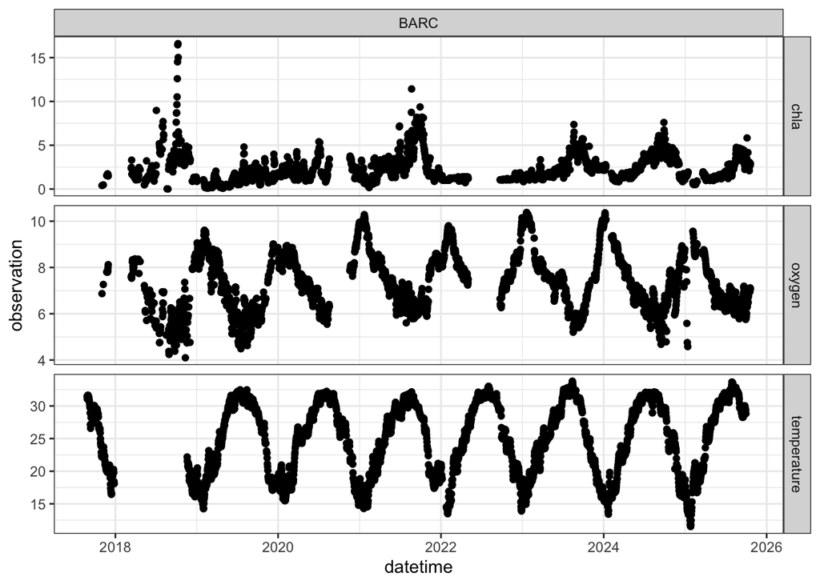

```r
forecast_url <- "https://sdsc.osn.xsede.org/bio230014-bucket01/challenges/targets/project_id=neon4cast/duration=P1D/aquatics-targets.csv.gz"

# then run this line to see your targets
forecast_targets <- read_csv(forecast_url, show_col_types = FALSE)

aquatics_focal_sites <- "BARC"

#glimpse(forecast_targets)

forecast_targets |>
  filter(site_id %in% aquatics_focal_sites) |>
  ggplot(aes(x = datetime, y = observation)) +
  geom_point() +
  facet_grid(variable~site_id, scales = "free_y") +
  theme_bw()
```

## Step 1b: Visualizing targets

YOUR TURN: For each of your forecast targets, produce the code that visualizes each target over the course of 1-2 years:

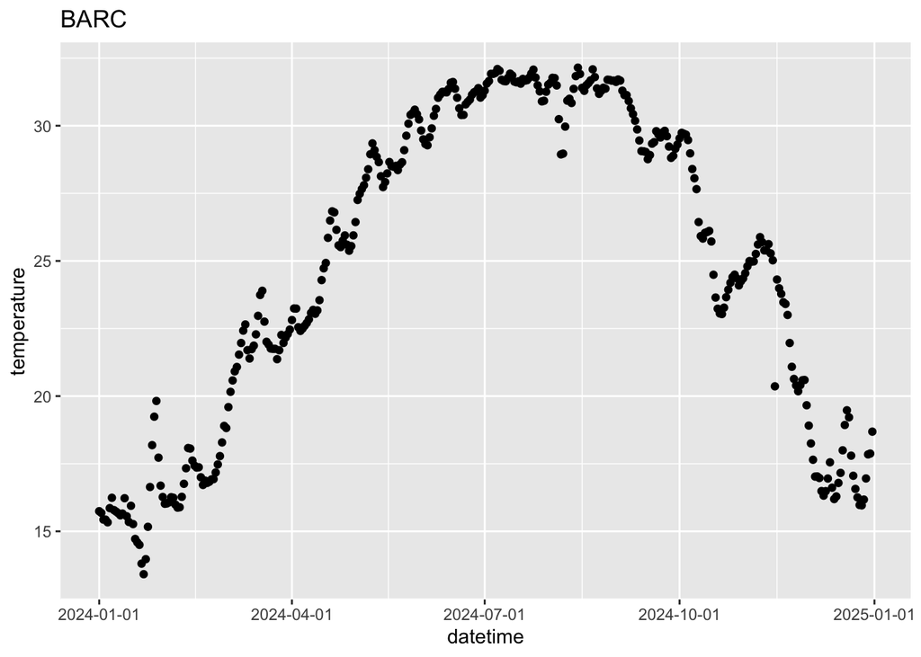

```r
forecast_variable <- "temperature"
neon_site <- "BARC"
site_year <- 2024

plot_targets(target_data = forecast_targets,
            measurement = forecast_variable,
            site = neon_site,
            year = site_year)
```

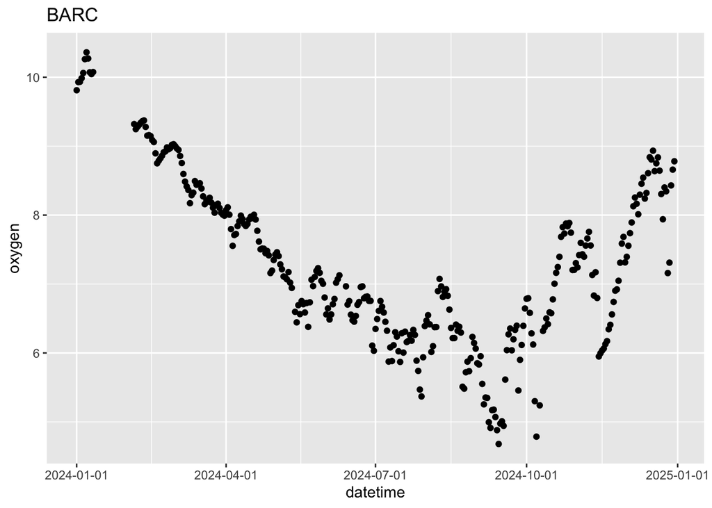

```r
forecast_variable <- "oxygen"

plot_targets(target_data = forecast_targets,
            measurement = forecast_variable,
            site = neon_site,
            year = site_year)
```

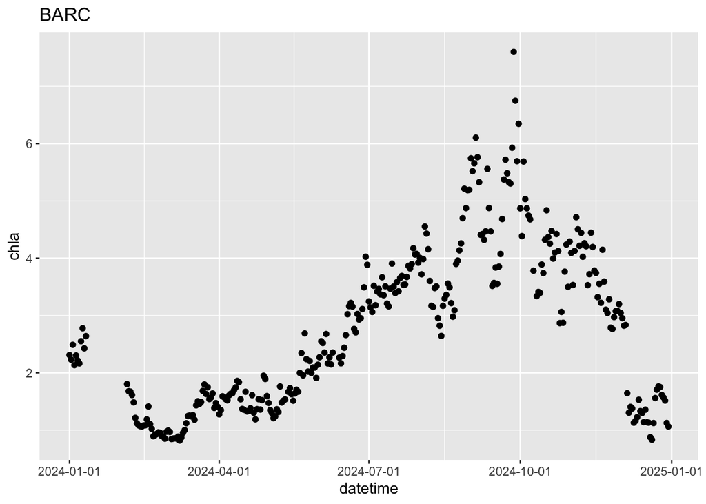

```r
forecast_variable <- "chla"

plot_targets(target_data = forecast_targets,
            measurement = forecast_variable,
            site = neon_site,
            year = site_year)
```

## Step 2: Get historical weather data

The next step is to visualize the effect of environmental variables on your targets to see if there are any possible relationships to explore. We use the historical weather data:

- `air_temperature` (K)
- `air_pressure` (Pa)
- `relative_humidity` (proportion)
- `surface_downwelling_longwave_flux_in_air` (W/m^2)
- `surface_downwelling_shortwave_flux_in_air` (W/m^2)
- `precipitation_flux` (kg/(m^2 s))
- `eastward_wind` (m/s)
- `northward_wind` (m/s)

YOUR TURN: Acquire the historical NOAA data for your site

```r
historical_noaa <- noaa_mean_historical(site = neon_site,
                                        year = site_year)
```

## Step 2b: Visualize historical weather data

YOUR TURN: Plot some NOAA environmental variables:

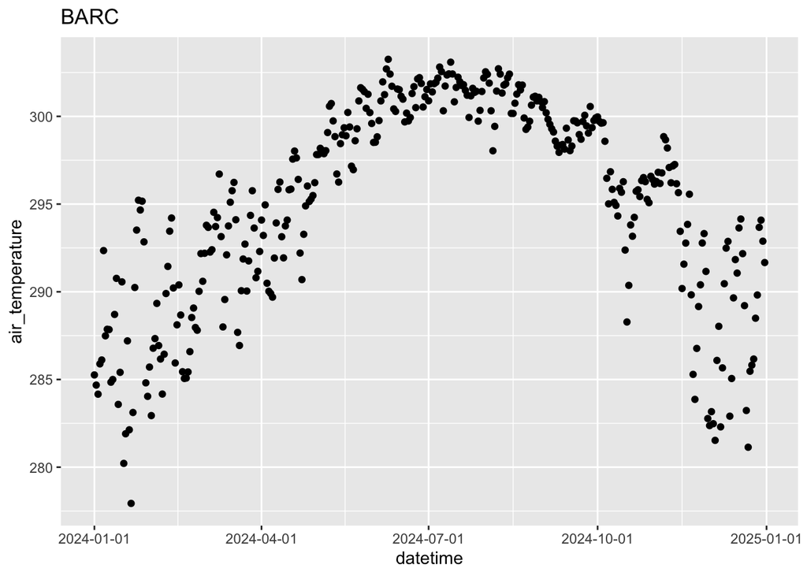

```r
forecast_variable <- "temperature"

noaa_measurement <- "air_temperature"


plot_noaa(noaa_data = historical_noaa,
          measurement = noaa_measurement,
          site = neon_site)
```

What patterns do you see? How do you imagine they affect your target?

## Step 3: Explore covariates

YOUR TURN: For each of the covariates you have identified, display the scatterplot.

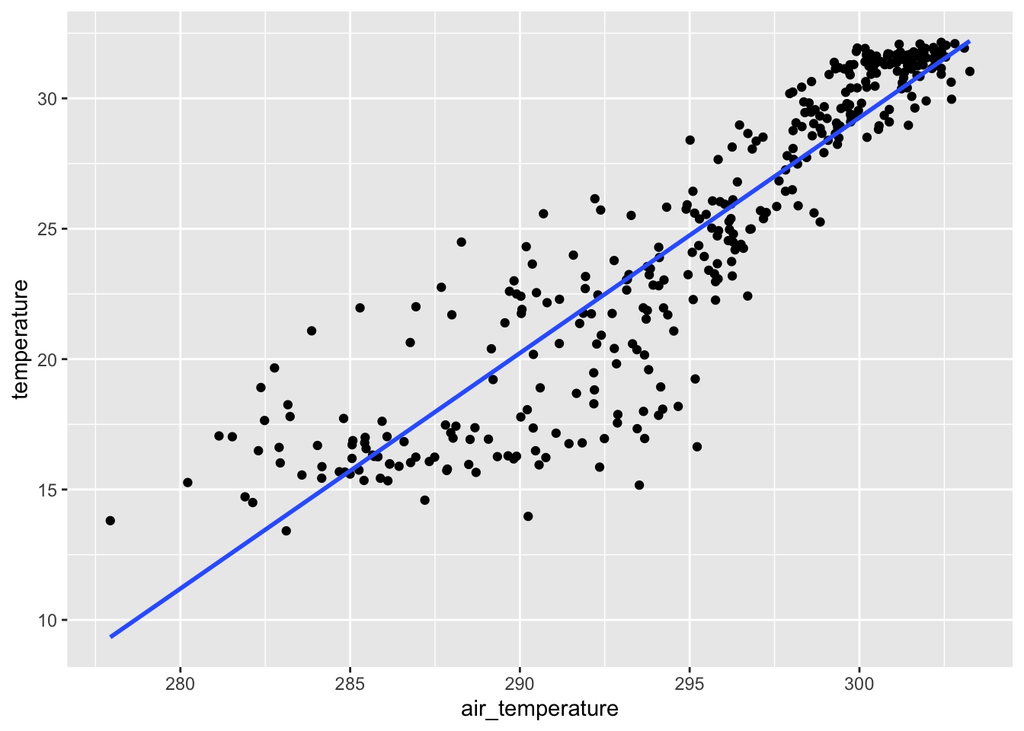

```r
noaa_measurement <- "air_temperature"

plot_target_noaa(target_data = forecast_targets,
                 noaa_data = historical_noaa,
                 noaa_variable = noaa_measurement,
                 target_variable = forecast_variable)
```

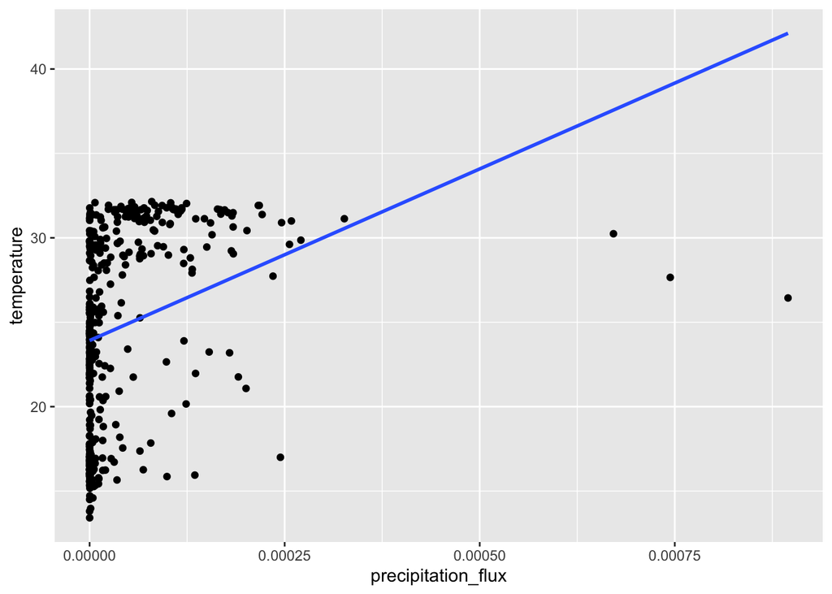

```r
noaa_measurement2 <- "precipitation_flux"
plot_target_noaa(target_data = forecast_targets,
                 noaa_data = historical_noaa,
                 noaa_variable = noaa_measurement2,
                 target_variable = forecast_variable)
```

## Step 4: Define regression model

YOUR TURN: Create the formula for your (linear) regression model for the target, and then create a model structure that fits the data.

```r
# TYPE YOUR RESPONSE HERE

regression_formula <- temperature ~ 1 + air_temperature

forecast_fit <- fit_lm_model(target_data = forecast_targets,
                             noaa_data = historical_noaa,
                             regression_equation = regression_formula)


summary(forecast_fit)
```

```
Call:
lm(formula = regression_equation, data = data_together)

Residuals:
    Min      1Q  Median      3Q     Max
-8.3075 -1.1343  0.3114  1.3469  6.3930

Coefficients:
                  Estimate Std. Error t value Pr(>|t|)
(Intercept)     -241.68694    6.16417  -39.21   <2e-16 ***
air_temperature    0.90317    0.02088   43.25   <2e-16 ***
---
Signif. codes:  0 '***' 0.001 '**' 0.01 '*' 0.05 '.' 0.1 ' ' 1

Residual standard error: 2.324 on 364 degrees of freedom
Multiple R-squared:  0.8371,    Adjusted R-squared:  0.8366
F-statistic:  1870 on 1 and 364 DF,  p-value: < 2.2e-16
```

YOUR TURN: How would you evaluate the regression fit, especially compared to the visualization of the targets with each covariate?

## Step 5: Acquire “future” forecast data

The next thing we need to do is to define a date, and then acquire what the future NOAA forecasts from the previous day. We make the forecasts beginning the day previous and then forecast into the future.

YOUR TURN: Select a day (preferably not recently), and then acquire the NOAA forecasts for that day:

```r
date_to_forecast <- "2024-01-01"
forecast_variables <- "air_temperature"

future <- get_forecast_noaa(site = neon_site,
                             forecast_date = date_to_forecast,
                             met_variables = forecast_variables)

glimpse(future)
```

```
Rows: 25,327
Columns: 6
$ parameter          <dbl> 0, 0, 0, 0, 0, 0, 0, 0, 0, 0, 0, 0, 0, 0, 0, 0, 0, …
$ datetime           <dttm> 2024-01-01 00:00:00, 2024-01-01 01:00:00, 2024-01-…
$ family             <chr> "ensemble", "ensemble", "ensemble", "ensemble", "en…
$ site_id            <chr> "BARC", "BARC", "BARC", "BARC", "BARC", "BARC", "BA…
$ reference_datetime <dttm> 2023-12-31, 2023-12-31, 2023-12-31, 2023-12-31, 20…
$ air_temperature    <dbl> 284.7149, 284.1475, 283.5801, 283.0128, 282.6558, 2…
```

## Step 6: Forecast

Now we are ready to evaluate the future NOAA data to our forecast model.

YOUR TURN: Assuming you have all the previous steps defined, all you need to do is uncomment the appropriate code:

```r
future_target <- make_prediction(noaa_future = future,
                                 fit_model = forecast_fit,
                                 target_variable = forecast_variable)

glimpse(future_target)
```

```
Rows: 25,327
Columns: 7
$ parameter          <dbl> 0, 0, 0, 0, 0, 0, 0, 0, 0, 0, 0, 0, 0, 0, 0, 0, 0, …
$ datetime           <dttm> 2024-01-01 00:00:00, 2024-01-01 01:00:00, 2024-01-…
$ family             <chr> "ensemble", "ensemble", "ensemble", "ensemble", "en…
$ site_id            <chr> "BARC", "BARC", "BARC", "BARC", "BARC", "BARC", "BA…
$ reference_datetime <dttm> 2023-12-31, 2023-12-31, 2023-12-31, 2023-12-31, 20…
$ prediction         <dbl> 15.45812, 14.94567, 14.43322, 13.92077, 13.59839, 1…
$ variable           <chr> "temperature", "temperature", "temperature", "tempe…
```

## Step 6b: Visualize forecasts

Let’s take a look at each of the ensemble forecasts.

YOUR TURN: Assuming you have all the previous steps defined, all you need to do is uncomment the appropriate code:

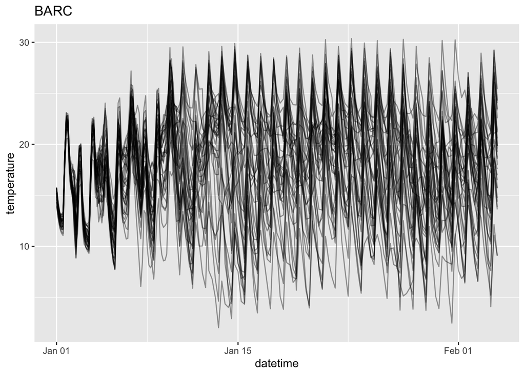

```r
 ggplot(data = future_target) +
   geom_line(aes(x=datetime,y=prediction,group=parameter),alpha=0.4) +
   ylab(forecast_variable) +
   ggtitle(neon_site)
```

YOUR TURN: How do you think your forecast does? What happens to the spread of the forecast as time goes on?

Our forecast is great initially but the spread quickly starts increasing, so it less precise further into the future.

## Step 7: Evaluate Forecast (next time!)